# Spatially optimised experimental designs with speed

AAGI Symposium 2026 workshop

Sam Rogers and Wasin Pipattungsakul

sam.rogers@adelaide.edu.au

November 11, 2026

## Remembrance Day

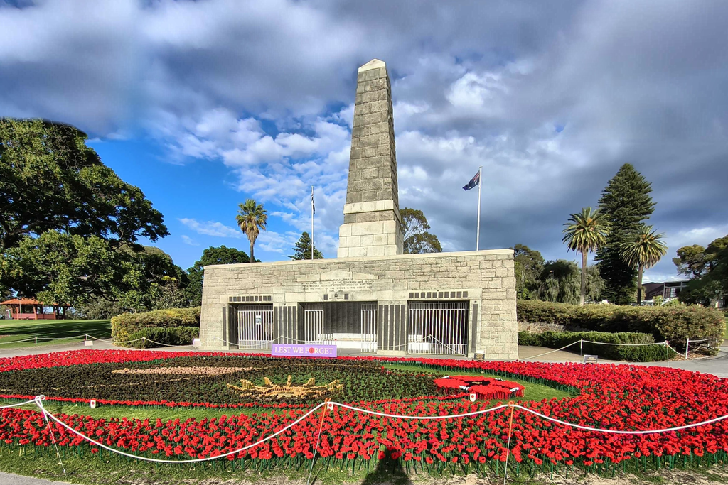

*Lest we forget*

1:00

## Plan for today

- Setup check
- Why spatial optimisation?
- How speed works
- Spatially optimised common designs
- Evaluating designs
- Designs with more complex structure
- MET designs
- Extensions (relationship matrices, custom objectives)
- Gotchas, getting help, Q&A

# Setup check

## Getting set up

- Workshop page: https://aagi-aus.github.io/speed-workshop/
- Slides and exercises are on that page. You can copy code from the slides.

```r
# install.packages("pak")
pak::pak("biometryhub/speed")
```

I will assume a working knowledge of experimental design, but please ask if something isn’t clear.

## Does it work for you?

```r
library(speed)
d <- initialise_design_df(4, 4, 4)
autoplot(speed(d,
      swap = "treatment",
      seed = 1))
```

```
Optimising level: single treatment within whole design
Optimal score reached at iteration 787 for level single treatment within whole design
```

[figure not shown]

# Why spatial optimisation?

## Field heterogeneity and neighbours

- Spatial trends are well known to exist in field trials<sup>1</sup>
- Neighbour effects impact treatments
- Spatially optimised designs guard against a sub-optimal randomisation
- Alternatives are not FOSS and/or lack documentation and/or features

[figure not shown]

[^1]: Gilmour, A. R., Cullis, B. R., & Verbyla, A. P. (1997). Accounting for Natural and Extraneous Variation in the Analysis of Field Experiments. *Journal of Agricultural, Biological, and Environmental Statistics, 2(3), 269–293.* https://doi.org/10.2307/1400446

## Restricted randomisation

- Impose some restrictions $\rightarrow$ improve spatial balance of treatments.
- Optimisation problem…

[figure not shown]

Systematic

[figure not shown]

Fully random

[figure not shown]

Restricted randomisation

# How speed works

## The workflow

1. Set up the layout (`initialise_design_df()` or otherwise)
2. `speed()`: optimise the layout
3. `autoplot()`: visualise it
4. `summary()`: evaluate it

## Four questions to ask of every design

| Question | Argument |
| --- | --- |
| What moves? | `swap`, `linked_cols`* |
| Where is it allowed to move to? | `swap_within` |
| What should it be balanced across? | `spatial_factors` |
| What counts as a ‘neighbour’? | `grid_factors` + `...` |

*: optional

## The default objective

- **Adjacency**: penalises the same treatment in neighbouring plots (*what counts as a neighbour?*)
- **Balance**: penalises a treatment repeating in the same rows or columns (*what should it be balanced across?*)
- Minimise the (optionally weighted) sum of these two components

## Simulated annealing in one slide

```
%%{init: {'theme': 'base', 'themeVariables': {'fontSize': '22px', 'fontFamily': 'Arial', 'lineColor': '#414042'}}}%%
flowchart LR
  A(["<span style='display:inline-block;padding:14px 30px;font-size:30px;font-weight:bold'>Design</span>"]) --> B["Swap two plots,<br/>score the new design"]
  B --> C{"Better?"}
  C -- "yes" --> D["Accept"]
  C -- "no" --> E["Sometimes accept<br/>(less often as it cools)"]
  D --> A
  E --> A
  A -- "optimal score or<br/>no improvement" --> H(["Stop"])

  classDef hub fill:#00808b,stroke:#004d54,stroke-width:5px,color:#ffffff
  classDef design fill:#00808b,stroke:#00808b,color:#ffffff
  classDef step fill:#f2f2f2,stroke:#00808b,color:#414042
  classDef good fill:#b6d438,stroke:#54921e,color:#414042
  classDef maybe fill:#ffbc42,stroke:#ec8525,color:#414042
  class A hub
  class H design
  class B,C step
  class D good
  class E maybe
```

[figure not shown]

# Spatially optimised common designs

## Spatially balanced design<sup>1</sup>: set up the layout

```r
sbd_design <- initialise_design_df(items = 8, nrows = 8, ncols = 4)
head(sbd_design)
```

```
  row col treatment
1   1   1        T1
2   2   1        T2
3   3   1        T3
4   4   1        T4
5   5   1        T5
6   6   1        T6
```

[^2]: Due to the restricted randomisation and optimisation applied to these designs, they are not strictly randomised, so this is not a completely randomised design. Hence we use slightly different terminology.

## SBD: the four questions

| Question | Argument | Input |
| --- | --- | --- |
| What moves? | `swap` | **`treatment`** |
| Where is it allowed to move to? | `swap_within` | default |
| What should it be balanced across? | `spatial_factors` | default |
| What counts as a ‘neighbour’? | `grid_factors` | default |

## SBD: optimise

```r
sbd_result <- speed(sbd_design,
                    swap = "treatment",
                    seed = 42)
```

```
Optimising level: single treatment within whole design
Optimal score reached at iteration 730 for level single treatment within whole design
```

```r
sbd_result
```

```
Optimised Experimental Design
----------------------------
Score: 2.285714
Iterations Run: 730
Stopped Early: TRUE
Treatments: T1, T2, T3, T4, T5, T6, T7, T8
Seed: 42
```

## SBD: plot

```r
autoplot(sbd_result)
```

[figure not shown]

## Spatially balanced block design: set up the layout

```r
sbbd_design <- initialise_design_df(
  items = paste0("V", 1:6),
  nrows = 4, ncols = 6,
  block_nrows = 1, block_ncols = 6
)
```

## SBBD: the four questions

| Question | Argument | Input |
| --- | --- | --- |
| What moves? | `swap` | **`treatment`** |
| Where is it allowed to move to? | `swap_within` | **`block`** |
| What should it be balanced across? | `spatial_factors` | default |
| What counts as a ‘neighbour’? | `grid_factors` | default |

## SBBD: optimise

```r
sbbd_result <- speed(sbbd_design,
                     swap = "treatment",
                     swap_within = "block",
                     seed = 42)
```

```
Optimising level: single treatment within block
Optimal score reached at iteration 329 for level single treatment within block
```

## SBBD layout

```r
autoplot(sbbd_result)
```

[figure not shown]

## Your turn

**Exercise 1** (about 10 minutes, on the Exercises page)

- 8 varieties × 4 replicates in a 4 × 8 field
- Each block is a **2 × 4 patch**, not a whole row
- Answer the four questions, optimise, and check each block has every variety once

# Evaluating designs

## `summary()`: structure and optimisation

`summary(sbbd_result)`, part 1 of 2

```
Design Summary
==============

Structure
---------
Layout:       4 rows x 6 cols (24 plots)
Treatments:   6
Replication:  4 each
Spatial:      row (4), col (6)

Optimisation
------------
Seed:         42
Objective:    objective_function
Score:        1.6  (initial 34 -> final 1.6)
              adjacency  0
              balance    1.6
Optimal:      1.6  (reached)
Iterations:   329 / 10,000 (optimal reached)
Temperature:  start 100, cooling 0.99
```

## `summary()`: evaluation

`summary(sbbd_result)`, part 2 of 2

```
Design Summary
==============

Evaluation
----------
Connected:    connected - treatment estimable given row + col + block [model (row + col + block)]
Concurrence:  complete blocks - not informative
Blk. spread:  each treatment in 4 of 4 blocks [block: block]
Repl. span:   worst-case 2 (row), 2 (col) across 6 replicated treatment(s)
Efficiency:   not requested (set efficiency = TRUE)
Self-adj.:    none
Neighbour:    min 1, max 4 over 15 pairs (variance 0.6952)
```

## What the sections tell you

- **Structure**: layout, replication, spatial factors
- **Optimisation**: final score split into adjacency and balance
- **Evaluation**: connectedness, concurrence, replicate span
- **Flags**: iteration cap reached, unequal replication, disconnected design

# Designs with more complex structure

## More complex design types

- Designs with hierarchy
- Designs with multiple treatments
- Designs with multiple sites

## Split-plot: describe the structure

```r
splits <- list(
  subplot   = list(items = letters[1:4], nrows = 1, ncols = 1),
  wholeplot = list(items = LETTERS[1:3], nrows = 1, ncols = 4),
  block     = list(nrows = 3, ncols = 4)
)
sp_design <- initialise_split_design_df(splits = splits, rep_dim = c(4, 1))
```

## Split-plot: the four questions

One answer per level (`wp`, then `sp`):

| Question | Argument | Whole plots | Subplots |
| --- | --- | --- | --- |
| What moves? | `swap` | **`wholeplot_treatment`** | **`subplot_treatment`** |
| Where? | `swap_within` | **`block`** | **`wholeplot`** |
| Balance | `spatial_factors` | default | default |
| Neighbour | `grid_factors` | default | default |

## Split-plot: optimise level by level

```r
optimise <- list(
  wp = list(
    swap        = "wholeplot_treatment",
    swap_within = "block",
    swap_all    = TRUE
  ),
  sp = list(
    swap        = "subplot_treatment",
    swap_within = "wholeplot"
  )
)

sp_result <- speed(sp_design,
  optimise = optimise,
  seed = 42)
```

```
Optimising level: wp
Level: wp Iteration: 1000 Score: 100 Best: 100 Since Improvement: 1000
Level: wp Iteration: 2000 Score: 100 Best: 100 Since Improvement: 2000
Early stopping at iteration 2000 for level wp
Optimising level: sp
Optimal score reached at iteration 570 for level sp
```

## Split-plot layout

[figure not shown]

## p-rep: any data frame will do

```r
prep_design <- data.frame(
  row   = rep(1:14, each = 10),
  col   = rep(1:10, times = 14),
  block = rep(rep(1:2, each = 5), 14),
  entry = c(rep("check", 10),           # 1 check, 10 replicates
            paste0("V", rep(1:30, 2)),  # 30 varieties, 2 replicates each
            paste0("V", 31:100))        # 70 varieties, 1 replicate each
)
```

## p-rep: the four questions

| Question | Argument | Input |
| --- | --- | --- |
| What moves? | `swap` | **`entry`** |
| Where? | `swap_within` | default |
| Balance | `spatial_factors` | **`~ block + row + col`** |
| Neighbour | `grid_factors` | default |

## p-rep: optimise

```r
prep_result <- speed(prep_design,
                     swap = "entry",
                     spatial_factors = ~ block + row + col,
                     seed = 42)
```

```
Optimising level: single entry within whole design
Level: single entry within whole design Iteration: 1000 Score: 3.41703 Best: 3.41703 Since Improvement: 0
Level: single entry within whole design Iteration: 2000 Score: 3.29703 Best: 3.29703 Since Improvement: 27
Level: single entry within whole design Iteration: 3000 Score: 3.29703 Best: 3.29703 Since Improvement: 1027
Early stopping at iteration 3973 for level single entry within whole design
```

## p-rep layout

```r
autoplot(prep_result, treatments = "entry")
```

[figure not shown]

## p-rep layout

[figure not shown]

## Also covered in the vignettes

- Split-split plot and strip-plot
- Incomplete block designs
- Row–column designs with blocking
- `linked_cols`: keep variety names with their codes

## Your turn

**Exercise 2** (about 10 minutes, on the Exercises page)

- 4 tillage methods (whole plots) × 3 varieties (subplots), in 3 blocks
- Answer the four questions **for each level**, then optimise
- Check every block has every tillage method once, and every whole plot every variety once

# MET designs

## Several sites, one treatment set

```r
all_treatments <- c(rep(1:50, 7), rep(51:57, 8))
met_design <- initialise_design_df(
  items = all_treatments,
  designs = list(
    a = list(nrows = 28, ncols = 5, block_nrows = 7,  block_ncols = 5),
    b = list(nrows = 20, ncols = 3, block_nrows = 10, block_ncols = 3),
    c = list(nrows = 20, ncols = 4, block_nrows = 10, block_ncols = 4),
    d = list(nrows = 15, ncols = 4, block_nrows = 5,  block_ncols = 4),
    e = list(nrows = 22, ncols = 3, block_nrows = 11, block_ncols = 3)
  )
)
met_design$site_col   <- paste(met_design$site, met_design$col,   sep = "_")
met_design$site_block <- paste(met_design$site, met_design$block, sep = "_")
```

## MET: the four questions

Two levels: first connect the sites, then balance within each site.

| Question | Argument | Connectivity | Balance |
| --- | --- | --- | --- |
| What moves? | `swap` | **`treatment`** | **`treatment`** |
| Where? | `swap_within` | default | **`site`** |
| Balance | `spatial_factors` | **`~ site`** | **`~ site_col + site_block`** |
| Neighbour | `grid_factors` | **`by = "site"`** | **`by = "site"`** |

## Optimise connectivity, then balance

MET Part 1

```r
optimise <- list(
  connectivity = list(
    spatial_factors = ~ site
  ),
  balance = list(
    swap_within     = "site",
    spatial_factors = ~ site_col + site_block
  )
)
```

## Optimise connectivity, then balance

MET Part 2

```r
met_result <- speed(
  data = met_design,
  swap = "treatment",
  optimise = optimise,
  grid_factors = list(dim1 = "row", dim2 = "col", by = "site"),
  early_stop_iterations = 5000,
  optimise_params = optim_params(random_initialisation = TRUE, adj_weight = 0),
  seed = 112, quiet = TRUE
)
```

## MET layout

[figure not shown]

# Extensions

## Relationship matrices

Treat related entries as partial repeats when scoring adjacency.

```r
items  <- paste0("T", 1:16)
groups <- setNames(rep(c("A", "B", "C", "D"), each = 4), items)
rel <- matrix(0, 16, 16, dimnames = list(items, items))
within <- c(A = 0.8, B = 0.4, C = 0.1, D = 0.0)
for (g in names(within)) rel[items[groups == g],
items[groups == g]] <- within[[g]]
diag(rel) <- 1
head(rel)
```

```
    T1  T2  T3  T4  T5  T6  T7  T8 T9 T10 T11 T12 T13 T14 T15 T16
T1 1.0 0.8 0.8 0.8 0.0 0.0 0.0 0.0  0   0   0   0   0   0   0   0
T2 0.8 1.0 0.8 0.8 0.0 0.0 0.0 0.0  0   0   0   0   0   0   0   0
T3 0.8 0.8 1.0 0.8 0.0 0.0 0.0 0.0  0   0   0   0   0   0   0   0
T4 0.8 0.8 0.8 1.0 0.0 0.0 0.0 0.0  0   0   0   0   0   0   0   0
T5 0.0 0.0 0.0 0.0 1.0 0.4 0.4 0.4  0   0   0   0   0   0   0   0
T6 0.0 0.0 0.0 0.0 0.4 1.0 0.4 0.4  0   0   0   0   0   0   0   0
```

## Relationship matrices: optimise

```r
rel_design <- initialise_design_df(items = rep(items, 4), nrows = 8, ncols = 8,
                                   block_nrows = 4, block_ncols = 4)
rel_result <- speed(rel_design, swap = "treatment", swap_within = "block",
                    relationship = rel, seed = 42, quiet = TRUE)

rel_result
```

```
Optimised Experimental Design
----------------------------
Score: 4.266667
Iterations Run: 3511
Stopped Early: TRUE
Treatments: T1, T2, T3, T4, T5, T6, T7, T8, T9, T10, T11, T12, T13, T14, T15, T16
Seed: 42
```

## Relationship matrices: the effect

[figure not shown]

Tiles show each treatment’s *relationship group* (A: highly related, D: unrelated) not *treatment*.

## Custom objectives

An objective returns a list with a `score`; lower is better.

```r
get_cooccurrence <- function(design_df, swap) {
  pairs <- unlist(lapply(unique(design_df$block), function(block) {
    combn(sort(as.character(design_df[design_df$block == block, swap])), 2,
          FUN = function(x) paste(x, collapse = ","))
  }))
  return(as.list(table(pairs)))
}

bibd_objective <- function(layout_df, swap, spatial_cols,
                           row_column = "row", col_column = "col", ...) {
  adj <- calculate_adjacency_score(layout_df, swap, row_column, col_column)
  bal <- calculate_balance_score(layout_df, swap, spatial_cols)
  pair_var <- var(as.numeric(get_cooccurrence(layout_df, swap)))
  return(list(score = round(adj + bal + 10 * pair_var, 10)))
}
```

## Custom objectives: a BIBD

```r
bibd_df <- initialise_design_df(items = 5, nrows = 3, ncols = 10,
                                block_nrows = 3, block_ncols = 1)
bibd_result <- speed(bibd_df, swap = "treatment",
                     spatial_factors = ~ block + row + col,
                     obj_function = bibd_objective,
                     optimise_params = optim_params(random_initialisation = TRUE),
                     seed = 42, quiet = TRUE)
unique(unlist(get_cooccurrence(bibd_result$design_df, "treatment")))
```

```
[1] 3
```

## Custom objectives: every pair together 3 times

[figure not shown]

T1 and T2 share a block exactly 3 times, like every other pair.

# Gotchas, getting help, Q&A

## Gotchas

- Treatment column not called `treatment`? Pass `treatments =` to `autoplot()`
- Companion columns (variety names) don’t move unless named in `linked_cols`
- MET sites reuse coordinates: set `grid_factors = list(..., by = "site")`
- Check `summary()` flags: a run that hit the iteration cap may need more `iterations`

## Getting help

- Documentation and vignettes: https://biometryhub.github.io/speed/
- Bugs and feature requests: https://github.com/biometryhub/speed/issues
- `?speed`, `?initialise_design_df`, `?optim_params`